# Evaluating land consolidation decision for smallholder farmers in Kenya

Hannah Kamau, Cory Whitney

# 1 Introduction

This document is a supplementary resource and contains the description of the land consolidation model used to simulate outcomes of the decision to consolidate land in Kenya by smallholder farmers. Data used in this model, is expert estimates collected in March 2024 after co-creating a conceptual model with the stakeholders and from published literature.

# 2 Install the necessary packages

Must have R packages are `decisionSupport` (Luedeling et al. 2024), `tidyverse` (Wickham 2023), and `ggplot2` (Wickham 2016).

```r
#Packages citation tied to a .bib file
knitr::write_bib(c(.packages(),
                   'decisionSupport',
                   'ggplot2',
                   'tidyverse',
                   'magrittr',
                   'kableExtra',
                   'DT',
                   'grid',
                   'scales'), 'bib/packages.bib')
```

# 3 Transcribing the conceptual model to a land consolidation function

Our conceptual model was co-created with stakeholders to reflect the costs, benefits, and risks that could arise when shifting from the small and highly diversified farms to a model where farmers consolidate their land under the management of someone else. Varied benefits and costs can be envisioned from the current system of small farms and from a model where farmers consolidate land. For example,

Costs that a farmer could incur in a land consolidated option

- Planning costs (legal fee, knowledge acquisition, stationery, printing)
- Loss of natural assets e.g., perennial plants such as trees
- Food costs not saved
- Household upkeep cost prior to the first payment
- Medical bills due to reduced active lifestyle

# 4 Transcribing conceptual model to a land consolidation function

Conceptual model co-created with stakeholders reflected the costs, benefits, and risks that could arise when shifting from the small and highly diversified farms to a model where farmers consolidate their land under the management of someone else. Varied benefits and costs can be envisioned from the current system of small farms and from a model where farmers consolidate land. For example,

Costs that a farmer could incur in a land consolidated option

- Planning costs (legal fee, knowledge acquisition)
- Loss of natural assets e.g., trees
- Food costs not saved
- Household upkeep cost prior to the first payment
- Medical bills due to reduced active lifestyle

Benefits that a farmer could get in a land consolidated option

- Lease income
- Saved production costs
- Alternative income from on or off farm activities
- Better childhood
- Social cohesion
- Saved medical bills related to land use accidents/diseases

Costs incurred by a farmer who remains in the current system of small farms, henceforth referred to as “do nothing” option

- Planning costs (Whether the farmer decides to change or not, (s)he will have incurred the cost of planning)
- Medical bills related to land use accidents/diseases ans stress
- Medical bills related to land use accidents/diseases
- Production costs

Benefits that accrue in the do nothing option

- Land security (calculated by the value of trees)
- Annual crop yield
- Saved food costs

The above options are also faced by risks. Risks facing farmers who shift include social risks as a result of freed time while risks associated with crops will face farmers in the do nothing option.

*Shifting to a land consolidation model, is for a period of 25 years. During this time frame, the farmer can longer farm on the piece of land consolidated, but can receive lease income commensurate to the size of the land.*

Below is a series of equations that define the above costs, benefits, and risks for both options in the function `land_consolidation_function`. The calculations help us find out land consolidation effects by calculating the difference between the options. This difference is the **decision** that can influence viability of land consolidation for the farmers. To calculate the decision, the below equation takes a wide range of inputs, which means, uncertainty is unavoidable.

```r
# function to make variables and test the model
# used only in model construction

make_variables <- function(est,n=1)
{x <- decisionSupport::random(rho=est,n=n)
for(i in colnames(x))assign(i, as.numeric(x[1,i]),envir=.GlobalEnv)}

make_variables(decisionSupport::estimate_read_csv(paste("Input_tables/land_consolidation_input.csv", sep=",")))
```

```r
# Source the function land_consolidation_function.R
source("Scripts/land_consolidation_function.R")
```

# 5 Monte Carlo simulation

Now we run a Monte Carlo simulation of the model function above using the inputs form the input table `land_consolidation_input.csv` (shows the variables used in the model function and their input given as ranges - lower and upper bound, and the type of distribution).

```r
mcSimulation_results <-  decisionSupport::mcSimulation(
  estimate = decisionSupport::estimate_read_csv(paste("Input_tables/land_consolidation_input.csv", sep=",")),
  model_function = land_consolidation_function,
  numberOfModelRuns = 1e4,
  functionSyntax = "plainNames")
```

# 6 Results of the simulation

## 6.1 Distribution of the outcomes

```r
y_output<- as.data.frame(mcSimulation_results$y)
x_output <- as.data.frame(mcSimulation_results$x)
mc_output <-cbind(y_output, x_output)
mc_output <- mc_output %>% mutate(NPV_per_ha = benefit_lc_kes/ha_per_hh,
                      No_NPV_per_ha = benefit_status_quo_kes/ha_per_hh,
                      NPV_per_ha_decision = net_benefit_lc_kes/ha_per_hh )

summarised_stats <-mc_output %>%
  select(NPV_per_ha, No_NPV_per_ha, NPV_per_ha_decision) %>%
  summarise(across(everything(),
                   list(
                     min= ~min(., na.rm = TRUE)/ 1e6,
                     q05 = ~ quantile (., 0.05, na.rm = TRUE)/ 1e6,
                     median = ~ median(., na.rm = TRUE)/ 1e6,
                     q95 = ~ quantile(., 0.95, na.rm = TRUE)/ 1e6,
                     max = ~ max(., na.rm = TRUE)/ 1e6,
                     pc_positive = ~mean(. > 0, na.rm = TRUE) * 100))) %>%
  pivot_longer(everything(),
               names_to = c("variable", "statistic"),names_pattern = "^(.*)_(.*)$",
               values_to = "value") %>%
  pivot_wider(names_from = statistic,
              values_from = value) %>%
  mutate(across(min:max, round, 2))
print(summarised_stats)
```

```
## # A tibble: 6 × 7
##   variable                     min    q05 median   q95    max positive
##   <chr>                      <dbl>  <dbl>  <dbl> <dbl>  <dbl>    <dbl>
## 1 NPV_per_ha              -5936.   -28.0    4.67 15.9    569.     NA
## 2 NPV_per_ha_pc              NA     NA     NA    NA       NA      76.7
## 3 No_NPV_per_ha              -4.69   1.45  10.7  58.2  11902.     NA
## 4 No_NPV_per_ha_pc           NA     NA     NA    NA       NA      98.0
## 5 NPV_per_ha_decision    -12946.   -86.4   -5.43  9.59   116.     NA
## 6 NPV_per_ha_decision_pc     NA     NA     NA    NA       NA      28.9
```

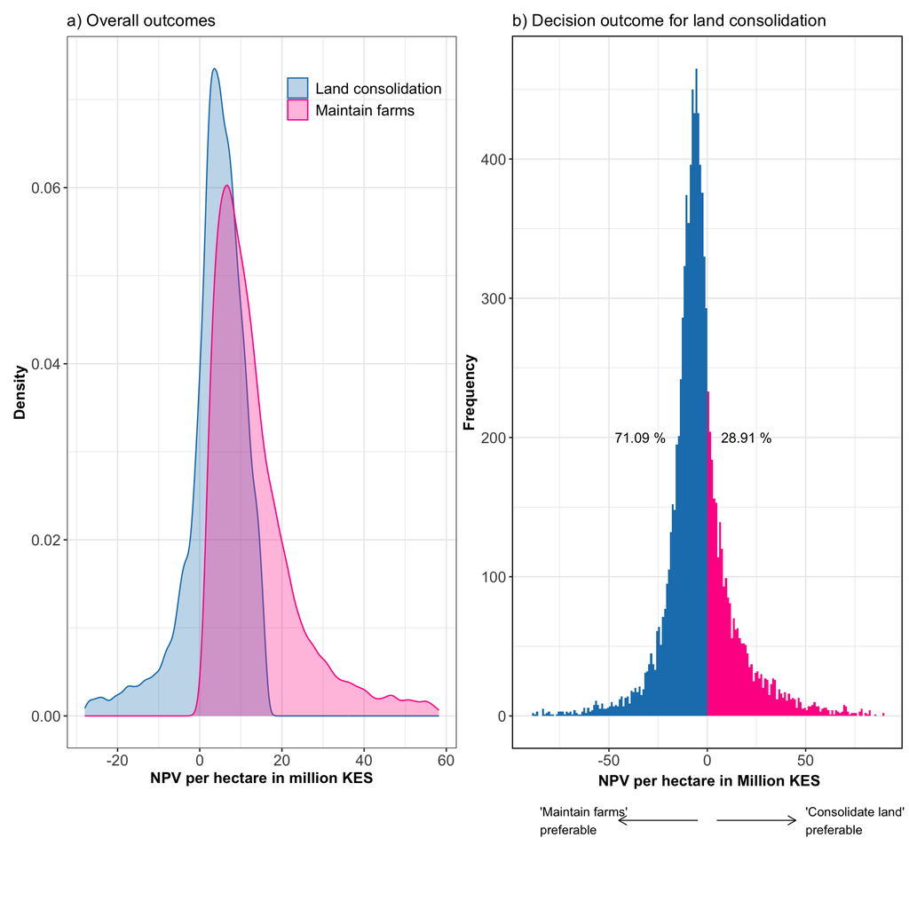

*Figure 1.* *Distribution of the outcomes given as net present value and expressed per hectare of land. (a) the distribution of land consolidation and do nothing options (b) distribution of the DECISION for land consolidation. The outcomes are based on 10,000 model runs generated through Monte Carlo simulation.*

```r
fig1a <- mc_output %>%
  select(NPV_per_ha, No_NPV_per_ha) %>%
  pivot_longer(., cols = c("NPV_per_ha", "No_NPV_per_ha"),
               names_to = "variables", values_to = "project_outcome") %>%
  group_by(variables) %>%
  mutate(lower_bound = quantile(project_outcome, 0.05, na.rm = T),
         upper_bound = quantile(project_outcome, 0.95, na.rm = T)) %>%
  filter(project_outcome >= lower_bound & project_outcome <= upper_bound) %>%
  ungroup() %>%
  mutate(variables = factor(variables,
                            levels=c('NPV_per_ha', 'No_NPV_per_ha'))) %>%
  ggplot(aes(x = project_outcome/1e6, colour = variables, fill = variables))+
  geom_density(alpha = 0.3)+
  theme_bw()+
  xlab("NPV per hectare in million KES") + ylab("Density")+
  ggtitle("a) Overall outcomes") +
  scale_colour_manual(name = "",
                    labels = c("Land consolidation","Maintain farms"),
                    values = c("#1a80bb", "deeppink"))+
  scale_fill_manual(name = "",
                      labels = c("Land consolidation","Maintain farms"),
                      values = c("#1a80bb", "deeppink"))+
  theme(legend.position = c(0.98, 0.98),
        legend.justification = c("right", "top"),
        legend.background = element_rect(fill = "transparent"),
        axis.title = element_text(size = 12, face = "bold"),
        axis.text = element_text(size = 12),
        legend.text = element_text(size = 12))

ggsave("figures/overall_distribution.png", dpi = 300)

# Decision land consolidate

percentages <- mc_output %>%
  select(net_benefit_lc_kes) %>%
  summarise(
    negative = sum(net_benefit_lc_kes < 0, na.rm = TRUE) / n() * 100,
    positive = sum(net_benefit_lc_kes >= 0, na.rm = TRUE) / n() * 100)

negative_percent <- round(percentages$negative, 2)
positive_percent <- round(percentages$positive, 2)

custom_colors <- c("negative" = "#1a80bb", "positive" = "deeppink") #pink
fig1b <- mc_output %>%
  mutate(outcome_category = ifelse(net_benefit_lc_kes >= 0, "positive","negative")) %>%
  select(net_benefit_lc_kes, outcome_category) %>%
  pivot_longer(., cols ="net_benefit_lc_kes",
               names_to = "variables", values_to = "project_outcome") %>%
  # group_by(variables) %>%
  # mutate(lower_bound = quantile(project_outcome, 0.05, na.rm = T),
  #        upper_bound = quantile(project_outcome, 0.95, na.rm = T)) %>%
  # filter(project_outcome >= lower_bound & project_outcome <= upper_bound) %>%
  # ungroup() %>%
  ggplot(aes(x=project_outcome/1e6, fill = outcome_category)) +
  geom_histogram(breaks=seq(-90,90, by=1)) +
  scale_fill_manual(values = custom_colors) +
  guides(fill = FALSE)+
  labs(x=" NPV per hectare in Million KES", y = "Frequency") +
  annotate(geom = "text",label = paste0(negative_percent, " %"), x = -34, y = 200,color = "black") +
  annotate(geom = "text", label = paste0(positive_percent, " %"), x = 20, y = 200,color = "black") +
  theme_bw() + ggtitle("b) Decision outcome for land consolidation") +
   theme(plot.margin = margin(0, 0, 90, 0),
        axis.title.x = element_text(margin = margin(t = 5))) +
  coord_cartesian(clip = "off") +  # Allow annotations outside plot area
  annotation_custom(grob = linesGrob(arrow = arrow(length = unit(0.25, "cm"), type = "open"), #arrow facing right
                     gp = gpar(col = "black")), xmin = 5, xmax = 45, ymin = -75, ymax = -75) +
  annotation_custom(grob = textGrob("'Consolidate land' \npreferable",
                    x = unit(0.8, "npc"), y = unit(-0.1, "npc"),
                    just = "left", gp = gpar(fontsize = 10)), xmin = 50, xmax = 50, ymin = -75, ymax = -75 ) +
  annotation_custom(grob = linesGrob(x = unit(c(1, 0), "npc"),  # Reverse direction for arrow
                     arrow = arrow(length = unit(0.25, "cm"), type = "open"),
                     gp = gpar(col = "black")), xmin = -5, xmax = -45, ymin = -75, ymax = -75) +
  annotation_custom( grob = textGrob("'Maintain farms' \npreferable",
                    x = unit(0.8, "npc"), y = unit(-0.1, "npc"),
                    just = "left", gp = gpar(fontsize = 10)), xmin = -85, xmax = -85, ymin = -75, ymax = -75 ) +
  theme(axis.title = element_text(size = 12, face = "bold"),
        axis.text = element_text(size = 12))

fig1a + fig1b
```

```r
 ggsave("figures/decision_outcome.png", dpi = 300)
```

## 6.2 Variable of Importance and Expected Value of Perfect Information

```r
pls_result <- plsr.mcSimulation( object = mcSimulation_results,
                                resultName = names(mcSimulation_results$y[3]), ncomp = 1)
fig2a <- decisionSupport::plot_pls(pls_result,
    input_table = read.csv("Input_tables/land_consolidation_input.csv", sep=","),
                          threshold = 1,
    pos_color = "#1a80bb", #blue
    neg_color = "#ea801c") + #orange
  scale_y_discrete(labels = function(y) str_wrap(y, width = 15)) +
  ggtitle("a) Variable in Importance") +
  theme(axis.text = element_text(size = 10),
        axis.title = element_text(size = 12, face = 'bold'),
        legend.text = element_text(size = 12),
        legend.title = element_blank())

ggsave("figures/VIP.png",dpi = 300)
mcSimulation_table <- data.frame(mcSimulation_results$x, mcSimulation_results$y[1:3])
evpi <- decisionSupport::multi_EVPI(mc = mcSimulation_table,
                                    first_out_var = "benefit_lc_kes")
```

```
## [1] "Processing 3 output variables. This can take some time."
## [1] "Output variable 1 (benefit_lc_kes) completed."
## [1] "Output variable 2 (benefit_status_quo_kes) completed."
## [1] "Output variable 3 (net_benefit_lc_kes) completed."
```

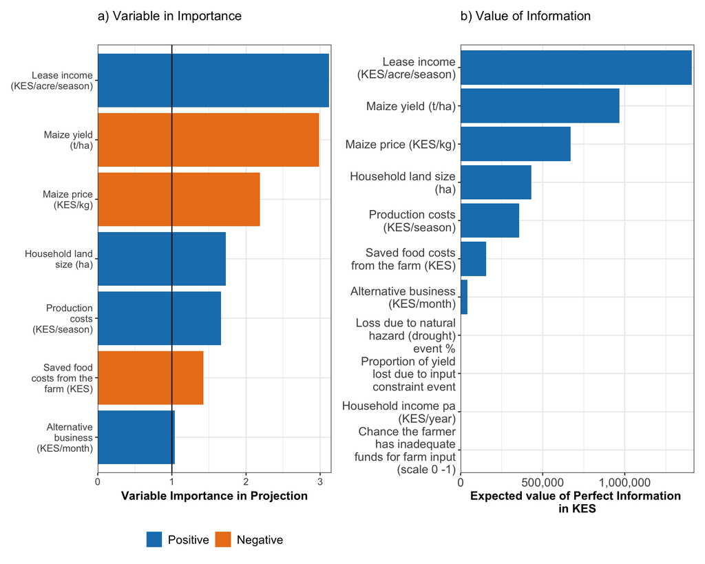

```r
fig2b<- plot_evpi(evpi, decision_vars = "net_benefit_lc_kes",
                  input_table = read.csv("Input_tables/land_consolidation_input.csv", sep = ","),
                  bar_color = "#1a80bb",
                  x_axis_name = "Expected value of Perfect Information \nin KES",
                  new_names = "") +
  scale_y_discrete(labels = function(y) str_wrap(y, width = 20)) +
  ggtitle("b) Value of Information") +
  theme(axis.title = element_text(size = 12, face = "bold"),
        axis.text = element_text(size = 12))
 fig2a + fig2b
```

```r
ggsave("figures/EVPI.png",dpi = 300)
```

# 7 Monte Carlo simulation with scenarios

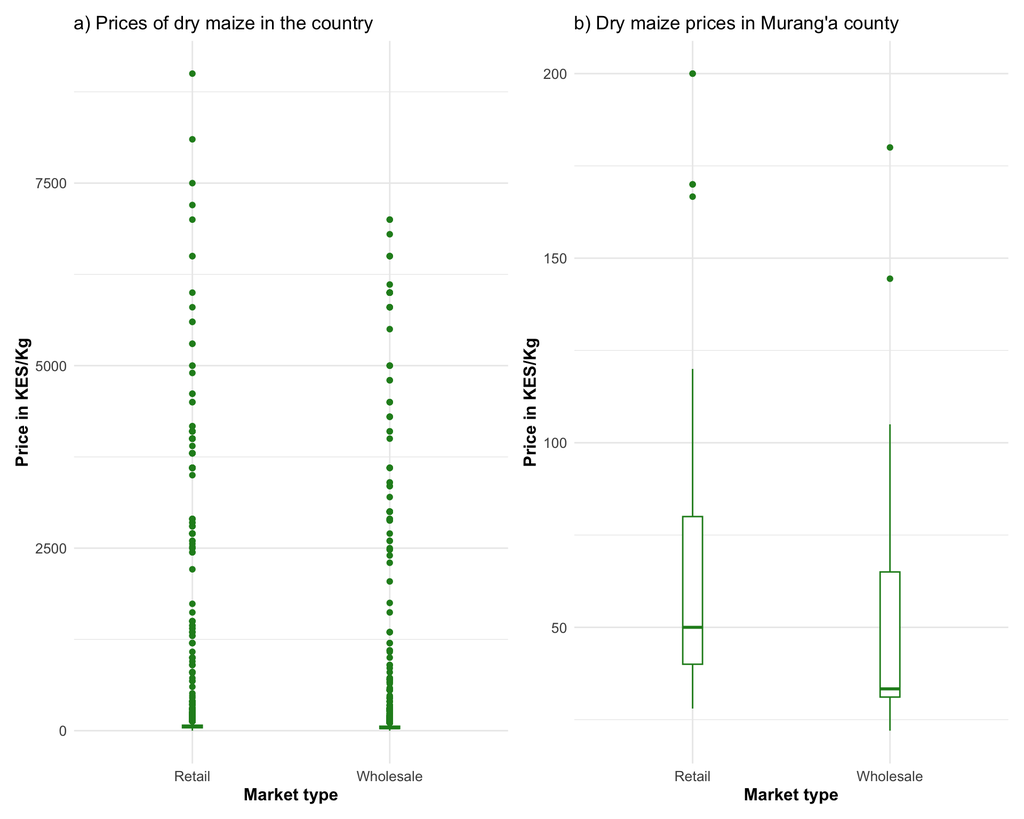

*Figure.S1.* *Distribution of dry white maize prices in Kenya (a) and in Murang’a country (b).*

```r
folder_path <- "Input_tables/maize_prices/"
csv_files <- list.files(path = folder_path, pattern = "*.csv", full.names = TRUE)

list_of_dfs <- lapply(csv_files, function(file) {
  read.csv(file, sep = ";")  # read the csv files into data frame.
})
# add a column with the file name to track the source of each data frame
list_of_dfs <- lapply(seq_along(list_of_dfs), function(i) {
  df <- list_of_dfs[[i]]
  df <- df %>%
    mutate(Supply.Volume = as.numeric(Supply.Volume))  # Convert to numeric
  df$source_file <- basename(csv_files[i])  # Adding file name as a new column to track the source
  return(df) })

combined_df <- bind_rows(list_of_dfs)

combined_df <- combined_df %>%
  mutate(
    Wholesale = gsub("/Kg", "", Wholesale),           # Remove "/Kg"
    Wholesale = gsub(",", "", Wholesale),             # Remove commas
    Wholesale = trimws(Wholesale),                    # Remove any leading/trailing whitespaces
    Wholesale = na_if(Wholesale, " -"),               # Convert " - " to NA
    Wholesale = as.numeric(Wholesale),                # Convert to numeric
    Retail = gsub("/Kg", "", Retail),                 # Same process for Retail
    Retail = gsub(",", "", Retail),
    Retail = trimws(Retail),
    Retail = na_if(Retail, " -"),
    Retail = as.numeric(Retail),
    Date = as.Date(Date))                             # Change the date to be date

country <- combined_df %>%
  select(Wholesale, Retail)  %>%
  pivot_longer(., cols = everything(), names_to = "market_type", values_to = "prices") %>%
  ggplot(aes(x=factor(market_type), y= prices))+
  geom_boxplot(width = 0.1, color = "forestgreen") +
  xlab("Market type") + ylab("Price in KES/Kg") +
  theme_minimal() +ggtitle("a) Prices of dry maize in the country")+
  theme(axis.title = element_text(size = 12, face = "bold"),
        axis.text = element_text(size = 10))

muranga <-combined_df %>% filter(County == "Muranga") %>%
  select(Wholesale, Retail)  %>%
  pivot_longer(., cols = everything(), names_to = "market_type", values_to = "prices") %>%
  ggplot(aes(x=factor(market_type), y= prices))+
  geom_boxplot(width = 0.1, color = "forestgreen") +
  xlab("Market type") + ylab("Price in KES/Kg") +
  theme_minimal() + ggtitle("b) Dry maize prices in Murang'a county")+
  theme(axis.title = element_text(size = 12, face = "bold"),
        axis.text = element_text(size = 10))

country+muranga
```

Within the `decisionSupport` is a function called `scenario_mc`, that allows one to create scenarios using specific variables. one has to create a separate .csv file with specific variables to be modified. Based on uncertain variables -maize and land prices- we created market prices scenario file `market_scenarios.csv`. The file is as below

*Table 1.* *Specific model input variables that need to be updated to generate the market scenarios. These variables are chosen based on the analysis of the value of information and the results of EVPI are as shown in Figure 2b. These variables are the most critical variables for the decision to consolidate land.*

```r
market_scenario_param <- read.csv("Input_tables/market_scenarios.csv", sep = ";")

market_scenario_param %>%
  datatable(extensions = "Buttons",
            options = list(dom = "Blfrtip",
                           buttons=c('copy', 'csv', 'excel'),
                           scrollX = TRUE,
                            autoWidth = TRUE),
            rownames=FALSE)
```

| Variable | param | Scen_1 | Scen_2 | Scen_3 | Scen_4 | Scen_5 | Scen_6 | Scen_7 | Scen_8 | Scen_9 | Scen_10 | Scen_11 | Scen_12 | Scen_13 | Scen_14 | Scen_15 | Scen_16 |
| --- | --- | --- | --- | --- | --- | --- | --- | --- | --- | --- | --- | --- | --- | --- | --- | --- | --- |
| maize_price_kes_kg | lower |  | 5 | 86.68 | 168.34 |  |  |  | 5 | 5 | 5 | 86.68 | 86.68 | 86.68 | 168.34 | 168.34 | 168.34 |
| maize_price_kes_kg | upper |  | 86.67 | 168.33 | 250 |  |  |  | 86.67 | 86.67 | 86.67 | 168.33 | 168.33 | 168.33 | 250 | 250 | 250 |
| maize_price_kes_kg | distribution | posnorm | unif | unif | unif |  |  |  | unif | unif | unif | unif | unif | unif | unif | unif | unif |
| compensation_income_pm_acre | lower |  |  |  |  | 10000 | 340001 | 670001 | 10000 | 340001 | 670001 | 10000 | 340001 | 670001 | 10000 | 340001 | 670001 |
| compensation_income_pm_acre | upper |  |  |  |  | 340000 | 670000 | 1000000 | 340000 | 670000 | 1000000 | 340000 | 670000 | 1000000 | 340000 | 670000 | 1000000 |
| compensation_income_pm_acre | distribution |  |  |  |  | posnorm | posnorm | posnorm | posnorm | posnorm | posnorm | posnorm | posnorm | posnorm | posnorm | posnorm | posnorm |

Running the `land_consolidation_function` model function with the updated .csv file which we refer to as Monte Carlo simulation with scenarios

```r
land_consolidation_scenarios <-scenario_mc(base_estimate = estimate_read_csv("Input_tables/land_consolidation_input.csv", sep=","),
                               scenarios = read.csv("Input_tables/market_scenarios.csv", sep =";"),
                               model_function = land_consolidation_function,
                               numberOfModelRuns = 10000,
                               functionSyntax = "plainNames")
```

## 7.1 Varying the price of maize per kg

NB: When the decision outcomes are positive (i.e., have positive values), land consolidation is preferred and when the outcomes are negative, do nothing option is preferable.

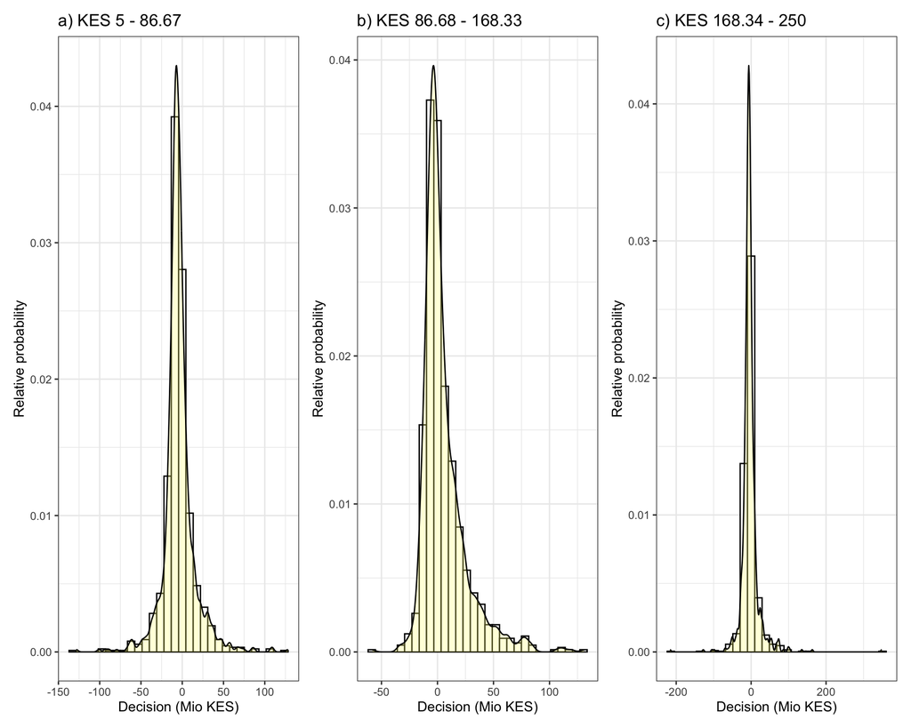

*Figure S2.* *The decision outcome of land consolidation when maize price is varied. The decision outcome is based on 1,000 model runs of land consolidation model function. Mio = Million.*

```r
scenarios <- read.csv("Input_tables/market_scenarios.csv", sep =";", fileEncoding = "UTF-8")
scen_1 <- scenarios[,c(1,2,3)]
scen1_consolidation <- scenario_mc(base_estimate = estimate_read_csv("Input_tables/land_consolidation_input.csv", sep=","),
                                   scenarios = scen_1,
                                   model_function = land_consolidation_function,
                                   numberOfModelRuns = 1000,
                                   functionSyntax = "plainNames")

fig3a <-ggplot(scen1_consolidation$y, aes(net_benefit_lc_kes/1000000))+
  geom_histogram(aes(y=..density..), color="black", fill = "white")+
  geom_density(alpha =.3, fill = "#FF8")+
  ylab("Relative probability") +
  xlab("Decision (Mio KES)") + theme_bw()+
  ggtitle("a) KES 5 - 86.67")


scen_2 <- scenarios[,c(1,2,4)]
scen2_consolidation <- scenario_mc(base_estimate = estimate_read_csv("Input_tables/land_consolidation_input.csv", sep=","),
                                   scenarios = scen_2,
                                   model_function = land_consolidation_function,
                                   numberOfModelRuns = 1000,
                                   functionSyntax = "plainNames")

fig3b <-ggplot(scen2_consolidation$y, aes(net_benefit_lc_kes/1000000))+
  geom_histogram(aes(y=..density..), color="black", fill = "white")+
  geom_density(alpha =.3, fill = "#FF8")+
  ylab("Relative probability") +
  xlab("Decision (Mio KES)") + theme_bw()+
  ggtitle("b) KES 86.68 - 168.33")


scen_3 <- scenarios[,c(1,2,5)]
scen3_consolidation <- scenario_mc(base_estimate = estimate_read_csv("Input_tables/land_consolidation_input.csv", sep=","),
                                   scenarios = scen_3,
                                   model_function = land_consolidation_function,
                                   numberOfModelRuns = 1000,
                                   functionSyntax = "plainNames")


fig3c <-ggplot(scen3_consolidation$y, aes(net_benefit_lc_kes/1000000))+
  geom_histogram(aes(y=..density..), color="black", fill = "white")+
  geom_density(alpha =.3, fill = "#FF8")+
  ylab("Relative probability") +
  xlab("Decision (Mio KES)") + theme_bw()+ ggtitle("c) KES 168.34 - 250")

fig3a + fig3b + fig3c
```

## 7.2 Varying the price of land per acre per season

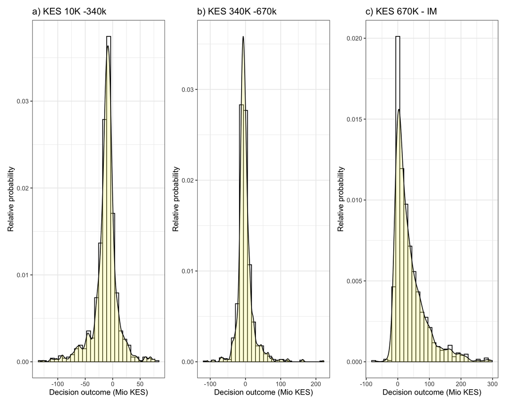

*Figure S3.* *The decision outcome of land consolidation when land price is varied. Outcome based on 1000 model runs of land consolidation model function. Mio = Million.*

```r
scen_4 <- scenarios[,c(1,2,6)]
scen4_consolidation <- scenario_mc(base_estimate = estimate_read_csv("Input_tables/land_consolidation_input.csv", sep=","),
                                   scenarios = scen_4,
                                   model_function = land_consolidation_function,
                                   numberOfModelRuns = 1000,
                                   functionSyntax = "plainNames")

scen4 <-ggplot(scen4_consolidation$y, aes(net_benefit_lc_kes/1000000))+
  geom_histogram(aes(y=..density..), color="black", fill = "white")+
  geom_density(alpha =.3, fill = "#FF8")+
  ylab("Relative probability") +
  xlab("Decision outcome (Mio KES)") + theme_bw()+
  ggtitle("a) KES 10K -340k")


scen_5 <- scenarios[,c(1,2,7)]
scen5_consolidation <- scenario_mc(base_estimate = estimate_read_csv("Input_tables/land_consolidation_input.csv", sep=","),
                                   scenarios = scen_5,
                                   model_function = land_consolidation_function,
                                   numberOfModelRuns = 1000,
                                   functionSyntax = "plainNames")

scen5 <-ggplot(scen5_consolidation$y, aes(net_benefit_lc_kes/1000000))+
  geom_histogram(aes(y=..density..), color="black", fill = "white")+
  geom_density(alpha =.3, fill = "#FF8")+
  ylab("Relative probability") +
  xlab("Decision outcome (Mio KES)") + theme_bw()+
  ggtitle("b) KES 340K -670k")

scen_6 <- scenarios[,c(1,2,8)]
scen6_consolidation <- scenario_mc(base_estimate = estimate_read_csv("Input_tables/land_consolidation_input.csv", sep=","),
                                   scenarios = scen_6,
                                   model_function = land_consolidation_function,
                                   numberOfModelRuns = 1000,
                                   functionSyntax = "plainNames")

scen6 <-ggplot(scen6_consolidation$y, aes(net_benefit_lc_kes/1000000))+
  geom_histogram(aes(y=..density..), color="black", fill = "white")+
  geom_density(alpha =.3, fill = "#FF8")+
  ylab("Relative probability") +
  xlab("Decision outcome (Mio KES)") + theme_bw()+
  ggtitle("c) KES 670K - IM")

scen4 + scen5 + scen6
```

## 7.3 Combinations of maize and land prices

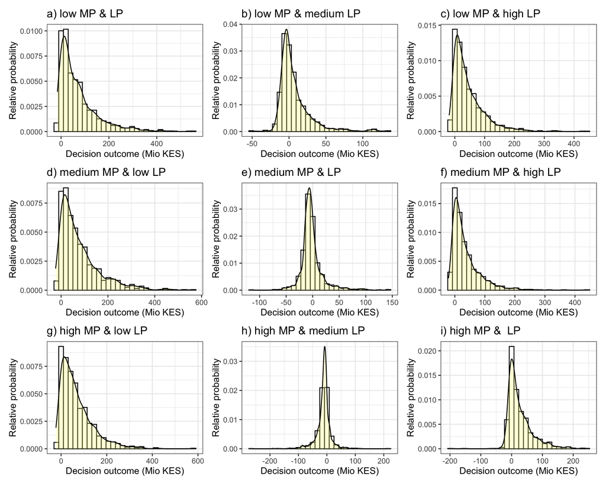

*Figure S4.* *The decision outcome of land consolidation when maize and land prices are varied. These outcomes are based on 1000 model runs of land consolidation model function. Mio = Million.*

```r
scen_7 <- scenarios[,c(1,2,9)]
scen7_consolidation <- scenario_mc(base_estimate = estimate_read_csv("Input_tables/land_consolidation_input.csv", sep=","),
                                   scenarios = scen_7,
                                   model_function = land_consolidation_function,
                                   numberOfModelRuns = 1000,
                                   functionSyntax = "plainNames")

scen7 <-ggplot(scen7_consolidation$y, aes(net_benefit_lc_kes/1000000))+
  geom_histogram(aes(y=..density..), color="black", fill = "white")+
  geom_density(alpha =.3, fill = "#FF8")+
  ylab("Relative probability") +
  xlab("Decision outcome (Mio KES)") + theme_bw()+
  ggtitle("a) low MP & LP")

scen_8 <- scenarios[,c(1,2,10)]
scen8_consolidation <- scenario_mc(base_estimate = estimate_read_csv("Input_tables/land_consolidation_input.csv", sep=","),
                                   scenarios = scen_8,
                                   model_function = land_consolidation_function,
                                    numberOfModelRuns = 1000,
                                   functionSyntax = "plainNames")

scen8 <-ggplot(scen8_consolidation$y, aes(net_benefit_lc_kes/1000000))+
  geom_histogram(aes(y=..density..), color="black", fill = "white")+
  geom_density(alpha =.3, fill = "#FF8")+
  ylab("Relative probability") +
  xlab("Decision outcome (Mio KES)") + theme_bw()+
  ggtitle("b) low MP & medium LP")

scen_9 <- scenarios[,c(1,2,11)]
scen9_consolidation <- scenario_mc(base_estimate = estimate_read_csv("Input_tables/land_consolidation_input.csv", sep=","),
                                   scenarios = scen_9,
                                   model_function = land_consolidation_function,
                                   numberOfModelRuns = 1000,
                                   functionSyntax = "plainNames")

scen9 <-ggplot(scen9_consolidation$y, aes(net_benefit_lc_kes/1000000))+
  geom_histogram(aes(y=..density..), color="black", fill = "white")+
  geom_density(alpha =.3, fill = "#FF8")+
  ylab("Relative probability") +
  xlab("Decision outcome (Mio KES)") + theme_bw()+
  ggtitle("c) low MP & high LP")

scen_10 <- scenarios[,c(1,2,12)]
scen10_consolidation <- scenario_mc(base_estimate = estimate_read_csv("Input_tables/land_consolidation_input.csv", sep=","),
                                   scenarios = scen_10,
                                   model_function = land_consolidation_function,
                                   numberOfModelRuns = 1000,
                                   functionSyntax = "plainNames")

scen10 <-ggplot(scen10_consolidation$y, aes(net_benefit_lc_kes/1000000))+
  geom_histogram(aes(y=..density..), color="black", fill = "white")+
  geom_density(alpha =.3, fill = "#FF8")+
  ylab("Relative probability") +
  xlab("Decision outcome (Mio KES)") + theme_bw()+
  ggtitle("d) medium MP & low LP")

scen_11 <- scenarios[,c(1,2,13)]
scen11_consolidation <- scenario_mc(base_estimate = estimate_read_csv("Input_tables/land_consolidation_input.csv", sep=","),
                                   scenarios = scen_11,
                                   model_function = land_consolidation_function,
                                   numberOfModelRuns = 1000,
                                   functionSyntax = "plainNames")

scen11 <-ggplot(scen11_consolidation$y, aes(net_benefit_lc_kes/1000000))+
  geom_histogram(aes(y=..density..), color="black", fill = "white")+
  geom_density(alpha =.3, fill = "#FF8")+
  ylab("Relative probability") +
  xlab("Decision outcome (Mio KES)") + theme_bw()+
  ggtitle("e) medium MP & LP")

scen_12 <- scenarios[,c(1,2,14)]
scen12_consolidation <- scenario_mc(base_estimate = estimate_read_csv("Input_tables/land_consolidation_input.csv", sep=","),
                                   scenarios = scen_12,
                                   model_function = land_consolidation_function,
                                   numberOfModelRuns = 1000,
                                   functionSyntax = "plainNames")

scen12 <-ggplot(scen12_consolidation$y, aes(net_benefit_lc_kes/1000000))+
  geom_histogram(aes(y=..density..), color="black", fill = "white")+
  geom_density(alpha =.3, fill = "#FF8")+
  ylab("Relative probability") +
  xlab("Decision outcome (Mio KES)") + theme_bw()+
  ggtitle("f) medium MP & high LP")

scen_13 <- scenarios[,c(1,2,15)]
scen13_consolidation <- scenario_mc(base_estimate = estimate_read_csv("Input_tables/land_consolidation_input.csv", sep=","),
                                   scenarios = scen_13,
                                   model_function = land_consolidation_function,
                                   numberOfModelRuns = 1000,
                                   functionSyntax = "plainNames")

scen13 <-ggplot(scen13_consolidation$y, aes(net_benefit_lc_kes/1000000))+
  geom_histogram(aes(y=..density..), color="black", fill = "white")+
  geom_density(alpha =.3, fill = "#FF8")+
  ylab("Relative probability") +
  xlab("Decision outcome (Mio KES)") + theme_bw()+
  ggtitle("g) high MP & low LP")

scen_14 <- scenarios[,c(1,2,16)]
scen14_consolidation <- scenario_mc(base_estimate = estimate_read_csv("Input_tables/land_consolidation_input.csv", sep=","),
                                   scenarios = scen_14,
                                   model_function = land_consolidation_function,
                                   numberOfModelRuns = 1000,
                                   functionSyntax = "plainNames")

scen14 <-ggplot(scen14_consolidation$y, aes(net_benefit_lc_kes/1000000))+
  geom_histogram(aes(y=..density..), color="black", fill = "white")+
  geom_density(alpha =.3, fill = "#FF8")+
  ylab("Relative probability") +
  xlab("Decision outcome (Mio KES)") + theme_bw()+
  ggtitle("h) high MP & medium LP")


scen_15 <- scenarios[,c(1,2,17)]
scen15_consolidation <- scenario_mc(base_estimate = estimate_read_csv("Input_tables/land_consolidation_input.csv", sep=","),
                                   scenarios = scen_15,
                                   model_function = land_consolidation_function,
                                   numberOfModelRuns = 1000,
                                   functionSyntax = "plainNames")

scen15 <-ggplot(scen15_consolidation$y, aes(net_benefit_lc_kes/1000000))+
  geom_histogram(aes(y=..density..), color="black", fill = "white")+
  geom_density(alpha =.3, fill = "#FF8")+
  ylab("Relative probability") +
  xlab("Decision outcome (Mio KES)") + theme_bw()+
  ggtitle("i) high MP &  LP")

(scen7 + scen8 + scen9)/
(scen10 + scen11 + scen12)/
(scen13 + scen14 +scen15)
```

# 8 Impact of the market price scenarios

Here, we compare the net benefit of land consolidation of different scenarios to the baseline net benefit of land consolidation. Table 2 shows the summary statistics of the net benefit for land consolidation, which can also be referred to as the decision of each scenario.

```r
land_consolidation_scenarios$y[,"net_benefit_lc_per_ha"] <- land_consolidation_scenarios$y$net_benefit_lc_kes/land_consolidation_scenarios$x$ha_per_hh #standardise to per ha
land_consolidation_scenarios$y[,"net_benefit_lc_per_ha_MKes"] <-land_consolidation_scenarios$y$net_benefit_lc_per_ha/1000000 # in millions for simplicity

mcSimulation_results$y[,"net_benefit_lc_per_ha"] <- mcSimulation_results$y$net_benefit_lc_kes/mcSimulation_results$x$ha_per_hh
mcSimulation_results$y[,"net_benefit_lc_per_ha_MKes"] <- mcSimulation_results$y$net_benefit_lc_per_ha/1000000
baseline_lc <- mcSimulation_results$y$net_benefit_lc_per_ha_MKes


low_mp <- land_consolidation_scenarios$y$net_benefit_lc_per_ha_MKes[land_consolidation_scenarios$x$Scenario == "Scen_1"]
med_mp <- land_consolidation_scenarios$y$net_benefit_lc_per_ha_MKes[land_consolidation_scenarios$x$Scenario == "Scen_2"]
high_mp <- land_consolidation_scenarios$y$net_benefit_lc_per_ha_MKes[land_consolidation_scenarios$x$Scenario == "Scen_3"]
low_lp <- land_consolidation_scenarios$y$net_benefit_lc_per_ha_MKes[land_consolidation_scenarios$x$Scenario == "Scen_4"]
med_lp <- land_consolidation_scenarios$y$net_benefit_lc_per_ha_MKes[land_consolidation_scenarios$x$Scenario == "Scen_5"]
high_lp <- land_consolidation_scenarios$y$net_benefit_lc_per_ha_MKes[land_consolidation_scenarios$x$Scenario == "Scen_6"]
low_mp_lp <-land_consolidation_scenarios$y$net_benefit_lc_per_ha_MKes[land_consolidation_scenarios$x$Scenario == "Scen_7"]
low_mp_med_lp <- land_consolidation_scenarios$y$net_benefit_lc_per_ha_MKes[land_consolidation_scenarios$x$Scenario == "Scen_8"]
low_mp_high_lp <- land_consolidation_scenarios$y$net_benefit_lc_per_ha_MKes[land_consolidation_scenarios$x$Scenario == "Scen_9"]
med_mp_low_lp <-land_consolidation_scenarios$y$net_benefit_lc_per_ha_MKes[land_consolidation_scenarios$x$Scenario == "Scen_10"]
med_mp_lp <- land_consolidation_scenarios$y$net_benefit_lc_per_ha_MKes[land_consolidation_scenarios$x$Scenario == "Scen_11"]
med_mp_high_lp <- land_consolidation_scenarios$y$net_benefit_lc_per_ha_MKes[land_consolidation_scenarios$x$Scenario == "Scen_12"]
high_mp_low_lp <- land_consolidation_scenarios$y$net_benefit_lc_per_ha_MKes[land_consolidation_scenarios$x$Scenario == "Scen_13"]
high_mp_med_lp <- land_consolidation_scenarios$y$net_benefit_lc_per_ha_MKes[land_consolidation_scenarios$x$Scenario == "Scen_14"]
high_mp_lp <- land_consolidation_scenarios$y$net_benefit_lc_per_ha_MKes[land_consolidation_scenarios$x$Scenario == "Scen_15"]


scenarios_summary <- rbind(data.frame("Baseline" = round(quantile(baseline_lc, c(0,0.05, 0.5, 0.95, 1)),2),
                                      "Low maize prices"=round(quantile(low_mp, c(0,0.05,0.5,0.95,1)),2),
                                      "Medium maize prices"=round(quantile(med_mp,c(0, 0.05,0.5,0.95,1)),2),
                                      "High maize prices"=round(quantile(high_mp, c(0,0.05, 0.5, 0.95,1)),2),
                                      "Low lease prices"=round(quantile(low_lp, c(0,0.05, 0.5,0.95,1)),2),
                                      "Medium lease prices"=round(quantile(med_lp, c(0,0.05,0.5,0.95,1)),2),
                                      "High lease prices"=round(quantile(high_lp, c(0,0.05,0.5,0.95,1)),2),
                                      "Low maize and lease prices"=round(quantile(low_mp_lp, c(0,0.05,0.5,0.95,1)),2),
                                      "Low MP and medium LP"=round(quantile(low_mp_med_lp, c(0,0.05,0.5,0.95,1)),2),
                                      "Low MP and high LP"= round(quantile(low_mp_high_lp, c(0,0.05,0.5,0.95,1)),2),
                                      "Medium MP and low LP"=round(quantile(med_mp_low_lp, c(0,0.05,0.5,0.95,1)),2),
                                      "Medium MP and LP"=round(quantile(med_mp_lp, c(0,0.05,0.5,0.95,1)),2),
                                      "Medium Mp and high LP"=round(quantile(med_mp_high_lp, c(0,0.05,0.5,0.95,1)),2),
                                      "High MP and low LP"=round(quantile(high_mp_low_lp, c(0,0.05,0.5,0.95,1)),2),
                                      "High MP and medium LP"=round(quantile(high_mp_med_lp, c(0,0.05,0.5,0.95,1)),2),
                                      "High MP and LP"=round(quantile(high_mp_lp, c(0,0.05,0.5,0.95,1)),2)))

scenarios_summary <- t(scenarios_summary)
scenarios_summary_df <- as.data.frame(scenarios_summary)
quantile_labels <- c("Minimum", "5% quantile", "Median", "95% quantile", "Maximum")
colnames(scenarios_summary_df) <- quantile_labels
rownames(scenarios_summary_df) <- gsub("\\.", " ", rownames(scenarios_summary_df)) # Replace periods with spaces in variable names

scenarios_summary_df <- cbind("Market price scenarios" = rownames(scenarios_summary_df), scenarios_summary_df, row.names=NULL)


kable(scenarios_summary_df, format = 'html',
  caption = "<p style='color:black'><i><b>Table 2.</b> Summary statistics of the net benefit for land consolidation of different market price scenarios. Based on 1000 model runs. Net benefit given in million KES</i></p>",
  align = c("l", rep("c", ncol(scenarios_summary_df) - 1))) %>%
  kable_styling(full_width = FALSE,
                bootstrap_options = c("striped", "hover")) %>%
  add_header_above(c("Market Price Scenarios" = 1, "Quantiles" = ncol(scenarios_summary_df) -1), underline = TRUE) %>%
  row_spec(nrow(scenarios_summary_df), hline_after = TRUE)
```

| Market Price Scenarios Market price scenarios | Quantiles Minimum | Quantiles 5% quantile | Quantiles Median | Quantiles 95% quantile | Quantiles Maximum |
| --- | --- | --- | --- | --- | --- |
| Baseline | -12946.24 | -86.44 | -5.43 | 9.59 | 115.56 |
| Low maize prices | -27585.55 | -83.53 | -5.06 | 9.61 | 995.50 |
| Medium maize prices | -49862.97 | -82.22 | 0.26 | 13.08 | 221.72 |
| High maize prices | -900746.79 | -87.81 | -5.49 | 9.27 | 1301.37 |
| Low lease prices | -76040.82 | -93.37 | -11.07 | 6.29 | 73.89 |
| Medium lease prices | -35196.05 | -92.47 | -4.28 | 13.31 | 1261.76 |
| High lease prices | -134643.13 | -61.22 | 16.15 | 34.75 | 1903.29 |
| Low maize and lease prices | -226306.45 | -43.51 | 33.91 | 55.79 | 280.44 |
| Low MP and medium LP | -35404.01 | -79.69 | 1.27 | 17.30 | 309.13 |
| Low MP and high LP | -84311.61 | -51.11 | 21.32 | 38.86 | 735.00 |
| Medium MP and low LP | -150685.59 | -42.57 | 38.74 | 60.73 | 238.85 |
| Medium MP and LP | -373654.37 | -84.52 | -4.29 | 12.35 | 132.17 |
| Medium Mp and high LP | -49403.75 | -65.91 | 15.63 | 34.31 | 138.23 |
| High MP and low LP | -37262.08 | -42.74 | 33.58 | 55.27 | 139.96 |
| High MP and medium LP | -36100.92 | -88.60 | -9.95 | 9.16 | 172.31 |
| High MP and LP | -46386.00 | -75.78 | 10.49 | 30.82 | 209.13 |

Preferable scenario for different market price scenarios were computed by the likelihood of a positive NPVs for the decision to consolidate land of each scenario.

```r
netbenefit_lc_all <- cbind(data.frame(baseline_lc, low_mp, med_mp,high_mp, low_lp, med_lp, high_lp, low_mp_lp,low_mp_med_lp, low_mp_high_lp,
                       med_mp_low_lp, med_mp_lp, med_mp_high_lp, high_mp_low_lp, high_mp_med_lp, high_mp_lp))

scenarios_names <- c(
  "baseline_lc" = "Baseline",
  "low_mp" = "Low MP", "med_mp" = "Medium MP", "high_mp" = "High MP",
  "low_lp" = "Low LP", "med_lp" = "Medium LP", "high_lp" = "High LP",
  "low_mp_lp" = "Low MP and LP", "low_mp_med_lp" = "Low MP and Medium LP",
  "low_mp_high_lp" = "Low MP and High LP", "med_mp_low_lp" = "Medium MP and Low LP",
  "med_mp_lp" = "Medium MP and LP", "med_mp_high_lp" = "Medium MP and High LP",
  "high_mp_low_lp" = "High MP and Low LP", "high_mp_med_lp" = "High MP and Medium LP",
  "high_mp_lp" = "High MP and LP")

netbenefit_lc_all %>%
  pivot_longer(cols = everything(), names_to = "scenarios", values_to = "net_benefit_lc") %>%
  mutate(scenarios = factor(scenarios, levels = names(scenarios_names)),
         scenarios = scenarios_names[scenarios]) %>%
  group_by(scenarios) %>%
  summarise(`without land consolidation preferable (%)` = mean(net_benefit_lc < 0, na.rm = TRUE) * 100,
            `with land consolidation preferable (%)` = mean(net_benefit_lc > 0, na.rm = TRUE) * 100,
            .groups = "drop") %>%
  pivot_longer(cols = -scenarios,
               names_to = "statistic",
               values_to = "value") %>%
  pivot_wider(names_from = statistic,
              values_from = value) %>%
  mutate(across(where(is.numeric), ~ round(.x, 2)))
```

```
## # A tibble: 16 × 3
##    scenarios             without land consolidation pre…¹ with land consolidat…²
##    <chr>                                            <dbl>                  <dbl>
##  1 Baseline                                         71.1                    28.9
##  2 High LP                                          18.4                    81.6
##  3 High MP                                          71.3                    28.7
##  4 High MP and LP                                   26.3                    73.7
##  5 High MP and Low LP                               10.2                    89.8
##  6 High MP and Medium LP                            79.9                    20.1
##  7 Low LP                                           84.1                    15.9
##  8 Low MP                                           69.6                    30.4
##  9 Low MP and High LP                               14.0                    86.0
## 10 Low MP and LP                                    10.2                    89.8
## 11 Low MP and Medium LP                             44.8                    55.2
## 12 Medium LP                                        64.5                    35.5
## 13 Medium MP                                        49.0                    51.0
## 14 Medium MP and High LP                            18.6                    81.4
## 15 Medium MP and LP                                 66.2                    33.8
## 16 Medium MP and Low LP                              8.97                   91.0
## # ℹ abbreviated names: ¹`without land consolidation preferable (%)`,
## #   ²`with land consolidation preferable (%)`
```

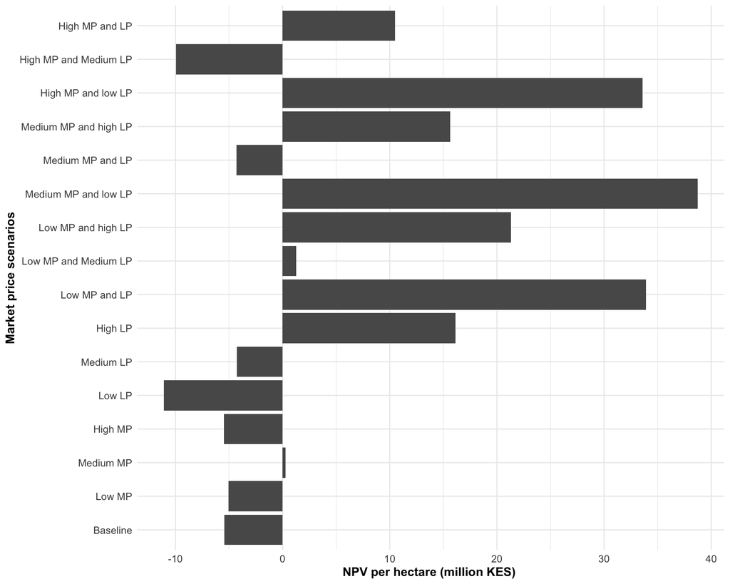

*Figure 3.* *The median values of the decision outcome of land consolidation when maize and land prices are varied. These outcomes are based on 10000 model runs of land consolidation model function.*

```r
netbenefit_lc_all %>%
  pivot_longer(cols = everything(), names_to = "scenarios", values_to = "net_benefit_lc") %>%
  group_by(scenarios) %>%
  mutate(scenarios = factor(scenarios, levels = c("baseline_lc","low_mp", "med_mp", "high_mp",
                                                  "low_lp", "med_lp", "high_lp",
                                                  "low_mp_lp", "low_mp_med_lp",
                                                  "low_mp_high_lp", "med_mp_low_lp",
                                                  "med_mp_lp", "med_mp_high_lp",
                                                  "high_mp_low_lp", "high_mp_med_lp",
                                                  "high_mp_lp"))) %>%
  ggplot(aes(x=scenarios, y= net_benefit_lc))+
  stat_summary(geom = 'col', fun = median)+
  geom_vline(xintercept = median(baseline_lc), color = "red", lwd =2 )+
  xlab("Market price scenarios") + ylab("NPV per hectare (million KES) ")+
  theme_minimal()+ coord_flip()+
  # theme(axis.text.x = element_text(angle = 90, vjust = 0.5, hjust = 1)) +
  scale_x_discrete(labels =c("low_mp" = "Low MP",
                             "med_mp" = "Medium MP",
                             "high_mp" = "High MP",
                             "low_lp" = "Low LP",
                             "med_lp" = "Medium LP",
                             "high_lp" = "High LP",
                             "low_mp_lp" = "Low MP and LP",
                             "low_mp_med_lp" = "Low MP and Medium LP",
                             "low_mp_high_lp" = "Low MP and high LP",
                             "med_mp_low_lp" = "Medium MP and low LP",
                             "med_mp_lp" = "Medium MP and LP",
                             "med_mp_high_lp" = "Medium MP and high LP",
                             "high_mp_low_lp" = "High MP and low LP",
                             "high_mp_med_lp" = "High MP and Medium LP",
                             "high_mp_lp" = "High MP and LP",
                             "baseline_lc" = "Baseline")) +
  theme(axis.title = element_text(size = 12, face = "bold"),
        axis.text = element_text(size = 10))
```

```r
 ggsave("figures/net_benefit_scenarios.png", dpi = 300)
```

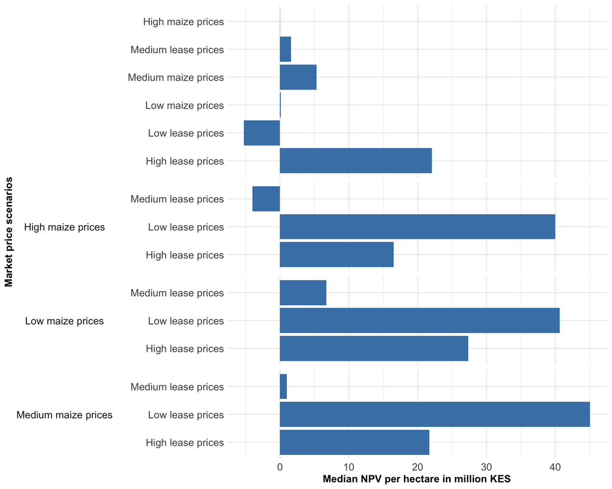

*Figure 4.* *Change in NPV of the decicision outcome for land consolidation given by the difference between outcomes of individual market price scenarios and baseline. Based on 10000 model runs of the land consolidation model function.*

```r
# mcSimulation_results$y[,"net_benefit_lc_per_ha"] <- mcSimulation_results$y$net_benefit_lc_kes/mcSimulation_results$x$ha_per_hh
# mcSimulation_results$y[,"net_benefit_lc_per_ha_MKes"] <- mcSimulation_results$y$net_benefit_lc_per_ha/1000000
# baseline_lc <- mcSimulation_results$y$net_benefit_lc_per_ha_MKes

netbenefit_lc <- cbind(data.frame(baseline_lc, low_mp, med_mp,high_mp, low_lp, med_lp, high_lp, low_mp_lp,low_mp_med_lp, low_mp_high_lp,
                       med_mp_low_lp, med_mp_lp, med_mp_high_lp, high_mp_low_lp, high_mp_med_lp, high_mp_lp))

netbenefit_lc[,"low_mp_change"] <- netbenefit_lc$low_mp-netbenefit_lc$baseline_lc
netbenefit_lc[,"med_mp_change"] <- netbenefit_lc$med_mp-netbenefit_lc$baseline_lc
netbenefit_lc[,"high_mp_change"] <-netbenefit_lc$high_mp-netbenefit_lc$baseline_lc
netbenefit_lc[,"low_lp_change"] <-netbenefit_lc$low_lp-netbenefit_lc$baseline_lc
netbenefit_lc[,"med_lp_change"]<-netbenefit_lc$med_lp-netbenefit_lc$baseline_lc
netbenefit_lc[,"high_lp_change"]<-netbenefit_lc$high_lp-netbenefit_lc$baseline_lc
netbenefit_lc[,"low_mp_lp_change"]<-netbenefit_lc$low_mp_lp-netbenefit_lc$baseline_lc
netbenefit_lc[,"low_mp_med_lp_change"]<-netbenefit_lc$low_mp_med_lp-netbenefit_lc$baseline_lc
netbenefit_lc[,"low_mp_high_lp_change"]<-netbenefit_lc$low_mp_high_lp-netbenefit_lc$baseline_lc
netbenefit_lc[,"med_mp_low_lp_change"]<-netbenefit_lc$med_mp_low_lp-netbenefit_lc$baseline_lc
netbenefit_lc[,"med_mp_lp_change"]<-netbenefit_lc$med_mp_lp-netbenefit_lc$baseline_lc
netbenefit_lc[,"med_mp_high_lp_change"]<-netbenefit_lc$med_mp_high_lp-netbenefit_lc$baseline_lc
netbenefit_lc[,"high_mp_low_lp_change"]<-netbenefit_lc$high_mp_low_lp-netbenefit_lc$baseline_lc
netbenefit_lc[,"high_mp_med_lp_change"]<-netbenefit_lc$high_mp_med_lp-netbenefit_lc$baseline_lc
netbenefit_lc[,"high_mp_lp_change"]<-netbenefit_lc$high_mp_lp-netbenefit_lc$baseline_lc

netbenefit_lc[,grep("_change$", colnames(netbenefit_lc))] %>%
  pivot_longer(cols = everything(), names_to = "market_prices", values_to = "lc_netbenefit_change") %>%
  mutate(
    market_prices=gsub("_change$", "", market_prices),
     market_theme = case_when(
      market_prices %in% c("low_mp", "med_mp", "high_mp", "low_lp", "med_lp", "high_lp") ~ "",
      market_prices %in% c("low_mp_lp", "low_mp_med_lp", "low_mp_high_lp") ~ "Low maize prices",
      market_prices %in% c("med_mp_low_lp", "med_mp_lp", "med_mp_high_lp") ~ "Medium maize prices",
      market_prices %in% c("high_mp_low_lp", "high_mp_med_lp", "high_mp_lp") ~ "High maize prices"),
    market_prices = case_when(
      market_prices == "low_mp" ~ "Low maize prices",
      market_prices == "med_mp" ~ "Medium maize prices",
      market_prices == "high_mp" ~ "High maize prices",
      market_prices == "low_lp" ~ "Low lease prices",
      market_prices == "med_lp" ~ "Medium lease prices",
      market_prices ==  "high_lp" ~ "High lease prices",
      market_prices ==  "low_mp_lp" ~ "Low lease prices",
      market_prices == "low_mp_med_lp" ~ "Medium lease prices",
      market_prices == "low_mp_high_lp" ~ "High lease prices",
      market_prices == "med_mp_low_lp" ~ "Low lease prices",
      market_prices == "med_mp_lp" ~ "Medium lease prices",
      market_prices == "med_mp_high_lp" ~ "High lease prices",
      market_prices == "high_mp_low_lp" ~ "Low lease prices",
      market_prices ==  "high_mp_med_lp" ~ "Medium lease prices",
      market_prices == "high_mp_lp" ~ "High lease prices")) %>%
  ggplot(aes(x=lc_netbenefit_change, y = reorder(market_prices, -lc_netbenefit_change)))+
  # ggplot(aes(x = lc_netbenefit_change, y = (reorder(market_prices, market_theme)))) +
  stat_summary(geom = "col", fun = median, fill = "steelblue") +
  facet_grid(market_theme ~ ., scales = "free_y", space = "free_y", switch = "y")+
  theme_minimal()+
  labs(x = "Median NPV per hectare in million KES", y = "Market price scenarios") +
  theme(strip.text.y.left = element_text(angle = 0, margin = margin(r =10), size = 12),
        strip.placement = "outside",
        axis.text.y = element_text(margin = margin(l = 5)),
        axis.title = element_text(size = 12, face = "bold"),
        axis.text = element_text(size = 12))
```

```r
 ggsave("figures/market_scenario_change.png", dpi = 300)
```

## References

Luedeling, Eike, Lutz Goehring, Katja Schiffers, Cory Whitney, and Eduardo Fernandez. 2024. *decisionSupport: Quantitative Support of Decision Making Under Uncertainty*. http://www.worldagroforestry.org/.

Wickham, Hadley. 2016. *Ggplot2: Elegant Graphics for Data Analysis*. Springer-Verlag New York. https://ggplot2.tidyverse.org.

———. 2023. *Tidyverse: Easily Install and Load the Tidyverse*. https://tidyverse.tidyverse.org.